# Built a classification model to cluster Engineering Colleges into different groups

## Problem Statement

Engg College Data file is provided. We need to do Clustering of the Engg Colleges on Hierarchical Clustering and K-Mean Clustering.

- Clustering using Hierarchical with Average Linkage.
- Clustering using K Means We need to Check the output of above two. If the output differs then what linkage can we use in Hierarchical so that the two output are almost matching.

## Solution

### Hierarchical Clustering with Average Linkage

### Importing the data file

```r
setwd(dirname(rstudioapi::getActiveDocumentContext()$path))
#getwd()
data = read.csv("Engg_College_Data.csv", header = TRUE)
head(data)
```

|  | SR_NO | Engg_College | Teaching | Fees | Placements | Internship | Infrastructure |
| --- | --- | --- | --- | --- | --- | --- | --- |
| 1 | 1 | A | 5 | 2 | 5 | 5 | 3 |
| 2 | 2 | B | 4 | 2 | 5 | 5 | 3 |
| 3 | 3 | C | 4 | 5 | 5 | 4 | 5 |
| 4 | 4 | D | 5 | 4 | 5 | 4 | 4 |
| 5 | 5 | E | 2 | 5 | 2 | 2 | 5 |
| 6 | 6 | F | 3 | 4 | 3 | 3 | 4 |

### Gathering some basic useful information about the dataset like its dimensions, data types and distribution, number of NAs etc.

```r
str(data)
```

```
'data.frame':   26 obs. of  7 variables:
 $ SR_NO         : int  1 2 3 4 5 6 7 8 9 10 ...
 $ Engg_College  : Factor w/ 26 levels "A","B","C","D",..: 1 2 3 4 5 6 7 8 9 10 ...
 $ Teaching      : int  5 4 4 5 2 3 1 4 4 3 ...
 $ Fees          : int  2 2 5 4 5 4 3 4 4 4 ...
 $ Placements    : int  5 5 5 5 2 3 1 5 4 3 ...
 $ Internship    : int  5 5 4 4 2 3 1 5 4 4 ...
 $ Infrastructure: int  3 3 5 4 5 4 2 5 4 5 ...
```

```r
summary(data)
```

```
     SR_NO        Engg_College    Teaching          Fees
 Min.   : 1.00   A      : 1    Min.   :1.000   Min.   :1.000
 1st Qu.: 7.25   B      : 1    1st Qu.:2.000   1st Qu.:2.250
 Median :13.50   C      : 1    Median :3.000   Median :4.000
 Mean   :13.50   D      : 1    Mean   :2.808   Mean   :3.577
 3rd Qu.:19.75   E      : 1    3rd Qu.:3.000   3rd Qu.:5.000
 Max.   :26.00   F      : 1    Max.   :5.000   Max.   :5.000
                 (Other):20
   Placements      Internship    Infrastructure
 Min.   :1.000   Min.   :1.000   Min.   :1.000
 1st Qu.:1.250   1st Qu.:2.000   1st Qu.:3.000
 Median :3.000   Median :2.000   Median :3.000
 Mean   :2.885   Mean   :2.769   Mean   :3.385
 3rd Qu.:4.000   3rd Qu.:4.000   3rd Qu.:4.750
 Max.   :5.000   Max.   :5.000   Max.   :5.000
```

```r
any(is.na(data))
```

```
[1] FALSE
```

### Scaling the dataset

```r
data.scale = scale(data[,-c(1,2)])
```

### Building the distance matrix

Since all the values here are continuous numerical values, you will use the euclidean distance method.

```r
data.dist.eucl = dist(x=data, method = "euclidean")
```

```
NAs introduced by coercion
```

```r
#print(data.dist.eucl, digits = 4)
```

### Applying Hierarchical Clustering

Applying hclust() function with “Average” linkage method and building the dendogram with 4 clusters

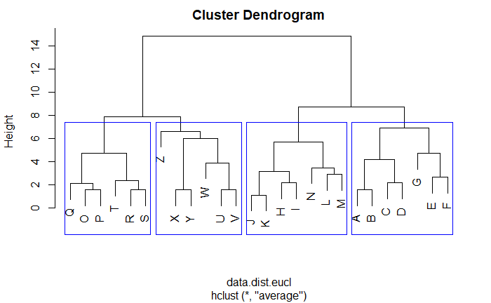

```r
data.hclus = hclust(d=data.dist.eucl, method = "average")
plot(x=data.hclus, labels = as.character(data[,2]))
rect.hclust(data.hclus, k=4, border = "blue")
```

### Profiling the clusters

```r
data$Cluster = cutree(data.hclus, k = 4)

aggr = aggregate(data[,-c(1,2,8)],list(data$Cluster),mean)

data.clus.profile = data.frame(Cluster = aggr[,1],
                               Freq = as.vector(table(data$Cluster)),
                               aggr[,-c(1)])
head(data.clus.profile)
```

|  | Cluster | Freq | Teaching | Fees | Placements | Internship | Infrastructure |
| --- | --- | --- | --- | --- | --- | --- | --- |
| 1 | 1 | 7 | 3.428571 | 3.571429 | 3.714286 | 3.428571 | 3.714286 |
| 2 | 2 | 7 | 2.857143 | 4.428571 | 3.142857 | 3.428571 | 4.000000 |
| 3 | 3 | 6 | 3.000000 | 3.666667 | 2.666667 | 2.333333 | 3.000000 |
| 4 | 4 | 6 | 1.833333 | 2.500000 | 1.833333 | 1.666667 | 2.666667 |

```r
NA
```

### K Means Clustering

Applying K Means clustering on the same dataset used for hierarchical clusting.

### Loading the dataset

```r
K_data = read.csv("D:/downloads/Engg_College_Data.csv", header = TRUE)
```

### Scaling the data and plotting the within groups sum of squares

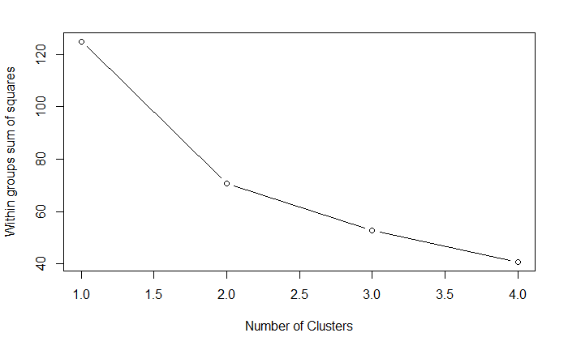

```r
K_data_scale = scale(K_data[,3:7])

wssplot = function(data, nc = 15 , seed = 1234){
  wss = (nrow(data)-1) * sum (apply(data, 2, var))
  for(i in 2:nc){
    set.seed(seed)
    wss[i] = sum(kmeans(data, centers = i)$withinss)
  }
  plot(1:nc, wss, type = "b", xlab = "Number of Clusters", ylab = "Within groups sum of squares")
}

wssplot(K_data_scale, nc = 4)
```

### Using NbClust library to find the number of clusters

```
*** : The Hubert index is a graphical method of determining the number of clusters.
                In the plot of Hubert index, we seek a significant knee that corresponds to a
                significant increase of the value of the measure i.e the significant peak in Hubert
                index second differences plot.
```

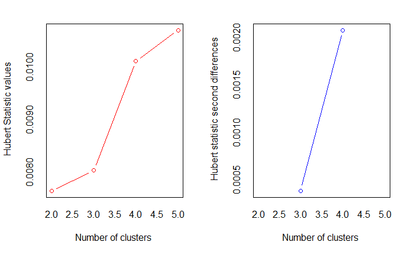

```
*** : The D index is a graphical method of determining the number of clusters.
                In the plot of D index, we seek a significant knee (the significant peak in Dindex
                second differences plot) that corresponds to a significant increase of the value of
                the measure.

* Among all indices:
* 10 proposed 2 as the best number of clusters
* 3 proposed 3 as the best number of clusters
* 8 proposed 4 as the best number of clusters
* 2 proposed 5 as the best number of clusters

                   ***** Conclusion *****

* According to the majority rule, the best number of clusters is  2
```

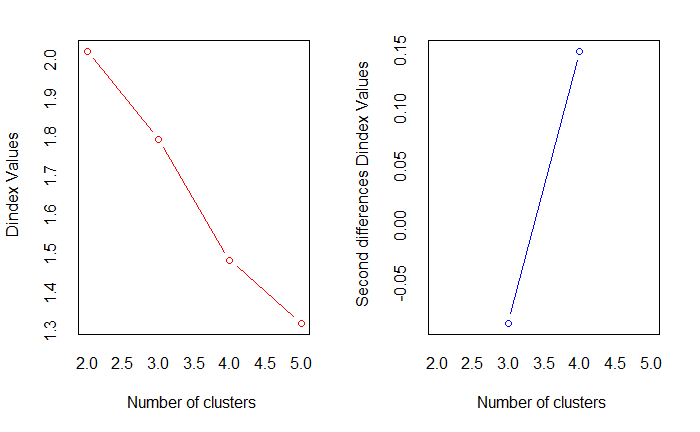

```r
library(NbClust)
set.seed(1234)
nc = NbClust(data = K_data[,3:7], min.nc = 2, max.nc = 5, method = "kmeans")
```

### Applying K Means

Applying K means with centers = 2, as - According to the majority rule, the best number of clusters is 2

```r
k_means_clus = kmeans(x= K_data_scale , centers = 2, nstart = 25)
k_means_clus
```

```
K-means clustering with 2 clusters of sizes 13, 13

Cluster means:
    Teaching       Fees Placements Internship Infrastructure
1 -0.7134772 -0.2599029 -0.8286332 -0.8046181     -0.4146733
2  0.7134772  0.2599029  0.8286332  0.8046181      0.4146733

Clustering vector:
 [1] 2 2 2 2 1 2 1 2 2 2 2 1 1 2 1 1 1 2 2 1 1 1 1 1 1 2

Within cluster sum of squares by cluster:
[1] 43.07600 27.77648
 (between_SS / total_SS =  43.3 %)

Available components:

[1] "cluster"      "centers"      "totss"        "withinss"
[5] "tot.withinss" "betweenss"    "size"         "iter"
[9] "ifault"
```

### Plotting the clusters

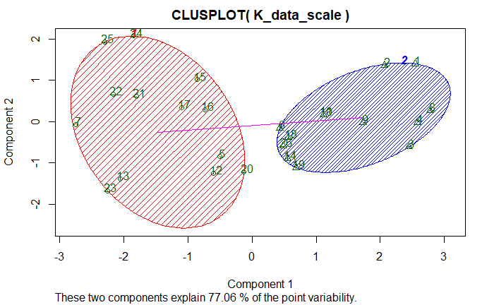

```r
library(cluster)
clusplot(K_data_scale, k_means_clus$cluster, color = TRUE, shade = TRUE, labels = 2, lines = 1)
```

### Profiling the dataset

```r
K_data$Cluster = k_means_clus$cluster

aggr = aggregate(K_data[,-c(1,2,8)],list(K_data$Cluster),mean)
K_data_clus_profile = data.frame(Cluster = aggr[,1],
                                 Freq = as.vector(table(K_data$Cluster)),
                                 aggr[,-c(1)])
head(K_data_clus_profile)
```

|  | Cluster | Freq | Teaching | Fees | Placements | Internship | Infrastructure |
| --- | --- | --- | --- | --- | --- | --- | --- |
| 1 | 1 | 13 | 2.000000 | 3.230769 | 1.615385 | 1.769231 | 2.846154 |
| 2 | 2 | 13 | 3.615385 | 3.923077 | 4.153846 | 3.769231 | 3.923077 |

### Applying K Means with centre = 4

Though after applying nbclust, the majority rule suggests cluster = 2, we found the clusters formed are not so much significant. Therefore, we will take the next majority, i.e. Cluster = 4 and apply K Means

```r
k_means_clus_4 = kmeans(x= K_data_scale , centers = 4, nstart = 25)
k_means_clus_4
```

```
K-means clustering with 4 clusters of sizes 10, 6, 8, 2

Cluster means:
      Teaching        Fees Placements  Internship Infrastructure
1 -0.006795021  0.69307450  0.2711891  0.02475748      0.3198908
2  1.347679233 -0.05775621  1.2722450  1.39260833      0.4739124
3 -0.603058144 -0.33931772 -0.9855713 -0.82009157     -1.0663028
4 -1.596830016 -1.93483297 -1.2303948 -1.02124611      1.2440199

Clustering vector:
 [1] 2 2 2 2 1 1 3 2 2 1 1 1 3 1 3 3 3 1 1 1 3 3 3 4 4 1

Within cluster sum of squares by cluster:
[1] 13.3906635  8.9670863 15.2634575  0.3237052
 (between_SS / total_SS =  69.6 %)

Available components:

[1] "cluster"      "centers"      "totss"        "withinss"
[5] "tot.withinss" "betweenss"    "size"         "iter"
[9] "ifault"
```

Again plotting the clusters

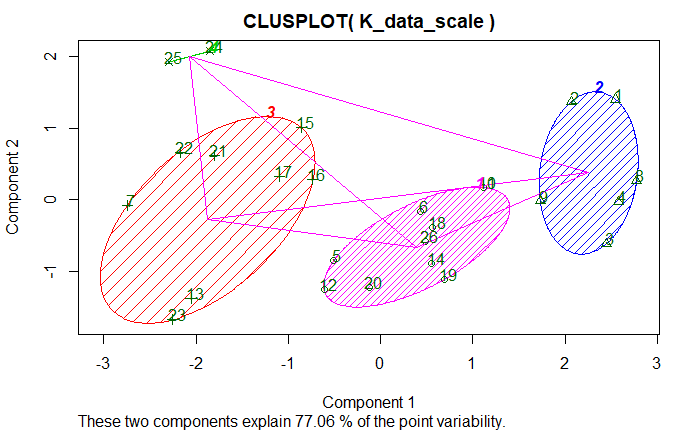

```r
clusplot(K_data_scale, k_means_clus_4$cluster, color = TRUE, shade = TRUE, labels = 2, lines = 1)
```

Then profiling the dataset with the updated findings

```r
K_data$Cluster = k_means_clus_4$cluster

aggr = aggregate(K_data[,-c(1,2,8)],list(K_data$Cluster),mean)
K_data_clus_profile = data.frame(Cluster = aggr[,1],
                                 Freq = as.vector(table(K_data$Cluster)),
                                 aggr[,-c(1)])
head(K_data_clus_profile)
```

|  | Cluster | Freq | Teaching | Fees | Placements | Internship | Infrastructure |
| --- | --- | --- | --- | --- | --- | --- | --- |
| 1 | 1 | 10 | 2.800000 | 4.500 | 3.300000 | 2.80 | 3.8 |
| 2 | 2 | 6 | 4.333333 | 3.500 | 4.833333 | 4.50 | 4.0 |
| 3 | 3 | 8 | 2.125000 | 3.125 | 1.375000 | 1.75 | 2.0 |
| 4 | 4 | 2 | 1.000000 | 1.000 | 1.000000 | 1.50 | 5.0 |

### Question : If the output differs then what linkage should have been used in Hierarchical so that the two output are almost matching.

To answer this, we have to re-run and check the Hierarchical clustering using different linkage method.

### Trying with Linkage = Complete

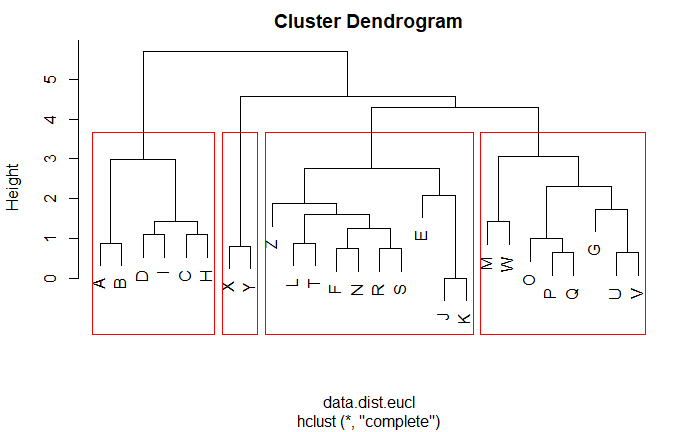

```r
data = read.csv("D:/downloads/Engg_College_Data.csv", header = TRUE)
data.scale = scale(data[,-c(1,2)])

data.dist.eucl = dist(x=data.scale, method = "euclidean")

data.hclus = hclust(d=data.dist.eucl, method = "complete")
plot(x=data.hclus, labels = as.character(data[,2]))
rect.hclust(data.hclus, k=4, border = "red")
```

```r
data$Cluster = cutree(data.hclus, k = 4)

aggr = aggregate(data[,-c(1,2,8)],list(data$Cluster),mean)
data.clus.profile = data.frame(Cluster = aggr[,1],
                               Freq = as.vector(table(data$Cluster)),
                               aggr[,-c(1)])
head(data.clus.profile)
```

|  | Cluster | Freq | Teaching | Fees | Placements | Internship | Infrastructure |
| --- | --- | --- | --- | --- | --- | --- | --- |
| 1 | 1 | 6 | 4.333333 | 3.500 | 4.833333 | 4.50 | 4.0 |
| 2 | 2 | 10 | 2.800000 | 4.500 | 3.300000 | 2.80 | 3.8 |
| 3 | 3 | 8 | 2.125000 | 3.125 | 1.375000 | 1.75 | 2.0 |
| 4 | 4 | 2 | 1.000000 | 1.000 | 1.000000 | 1.50 | 5.0 |

```r
NA
```

### Conclusion

In order to match the output of K Means Clustering (with cluster = 4) to Hierarchical Clustering (with cluster = 4), we have to use the linkage algorithm as “complete” for this dataset.